# ch10. N 차원 배열 다루기 1~3절

## 2.4 연속된 값을 갖는 1차원 배열 만들기

- np,arange(from, to, by, dtype): from부터 to앞까지 by씩 건너뛴 값을 1차원 배열로 생성
- np.linspace(from, to,num):

```python
np.arange(10,30,5,dtype=np.float64)
```

```
array([10., 15., 20., 25.])
```

```python
np.arange(0,2.1,0.3)
```

```
array([0. , 0.3, 0.6, 0.9, 1.2, 1.5, 1.8, 2.1])
```

```python
np.linspace(0,5,6)
```

```
array([0., 1., 2., 3., 4., 5.])
```

```python
# linspace: 특정 범위 수들을 많이 생성할 때
from numpy import pi, linspace
x=linspace(0,2*pi,10)
y=np.sin(x)
```

```python
y
```

```
array([ 0.00000000e+00,  6.42787610e-01,  9.84807753e-01,  8.66025404e-01,
        3.42020143e-01, -3.42020143e-01, -8.66025404e-01, -9.84807753e-01,
       -6.42787610e-01, -2.44929360e-16])
```

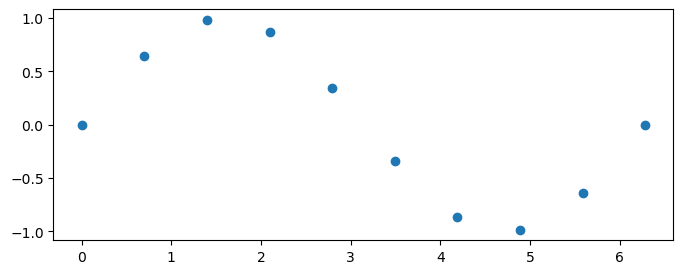

```python
plt.figure(figsize=(8,3))
plt.scatter(x,y)
plt.show()
```

## 2.5 배열의 차원 변경

- reshape(행수, 열수): -1 가능
- resize(행수, 열수): -1 불가
- T : 전치행렬로 변환
- transpose(): 전치행렬로 변환

```python
a.reshape(3,2)
```

```python
# 전치행렬 (x행 y열--> y행x열), 선행대수, 독립, 종속변수
a.T # a의 전치 행렬
```

```
---------------------------------------------------------------------------
AttributeError                            Traceback (most recent call last)
Cell In[154], line 2
      1 # 전치행렬 (x행 y열--> y행x열), 선행대수, 독립, 종속변수
----> 2 a.T

AttributeError: 'list' object has no attribute 'T'
```

```python
a.transpose()
```

## 2.6 배열 출력

```python
np.arange(1001)
```

```
array([   0,    1,    2, ...,  998,  999, 1000])
```

```python
# 배열 요소가 몇개까지 다 출력되나
np.get_printoptions()['threshold']
```

```
1000
```

```python
# 배열이 커서 인쇄가 안 되는 경우: 모서리부분만 출력
np.arange(10000).reshape(100,100)
```

```
array([[   0,    1,    2, ...,   97,   98,   99],
       [ 100,  101,  102, ...,  197,  198,  199],
       [ 200,  201,  202, ...,  297,  298,  299],
       ...,
       [9700, 9701, 9702, ..., 9797, 9798, 9799],
       [9800, 9801, 9802, ..., 9897, 9898, 9899],
       [9900, 9901, 9902, ..., 9997, 9998, 9999]])
```

```python
# 인쇄 옵션 변경
import sys
np.set_printoptions(threshold=sys.maxsize) # 정수 최대치까지 출력가능
np.set_printoptions(threshold=np.inf) # 무한대까지 출력가능
```

```python
np.arange(10000).reshape(100,100)
```

```
array([[   0,    1,    2,    3,    4,    5,    6,    7,    8,    9,   10,
          11,   12,   13,   14,   15,   16,   17,   18,   19,   20,   21,
          22,   23,   24,   25,   26,   27,   28,   29,   30,   31,   32,
          33,   34,   35,   36,   37,   38,   39,   40,   41,   42,   43,
          44,   45,   46,   47,   48,   49,   50,   51,   52,   53,   54,
          55,   56,   57,   58,   59,   60,   61,   62,   63,   64,   65,
          66,   67,   68,   69,   70,   71,   72,   73,   74,   75,   76,
          77,   78,   79,   80,   81,   82,   83,   84,   85,   86,   87,
          88,   89,   90,   91,   92,   93,   94,   95,   96,   97,   98,
          99],
       [ 100,  101,  102,  103,  104,  105,  106,  107,  108,  109,  110,
         111,  112,  113,  114,  115,  116,  117,  118,  119,  120,  121,
         122,  123,  124,  125,  126,  127,  128,  129,  130,  131,  132,
         133,  134,  135,  136,  137,  138,  139,  140,  141,  142,  143,
         144,  145,  146,  147,  148,  149,  150,  151,  152,  153,  154,
```

[output cut: 985 more lines]

## 2.7 기본 연산 동작

## 1) 배열의 요소별 연산

```python
import numpy as np
a=[10, 20, 30, 40]
b=list(range(4))
a+b, a*3
```

```
([10, 20, 30, 40, 0, 1, 2, 3],
 [10, 20, 30, 40, 10, 20, 30, 40, 10, 20, 30, 40])
```

```python
# numpy array
a=np.array([10, 20,30, 40])
b=np.arange(4)
a,b
```

```
(array([10, 20, 30, 40]), array([0, 1, 2, 3]))
```

```python
a+b # 요소별 연산
```

```
array([10, 21, 32, 43])
```

```python
a*3 # 요소별 *3 연산
```

```
array([ 30,  60,  90, 120])
```

```python
a*b # 요소별 * 연산
```

```
array([  0,  20,  60, 120])
```

```python
a**b # 요소별 ** 연산
```

```
array([    1,    20,   900, 64000])
```

```python
a
```

```
array([10, 20, 30, 40])
```

```python
a<40 # 각 요소별 연산
```

```
array([ True,  True,  True, False])
```

```python
a[0]
```

```
10
```

```python
a[[0,3]]
```

```
array([10, 40])
```

```python
a[[0,3]]
a[[True,False, False, True]]
```

```
array([10, 40])
```

```python
print(a[[0,3]])
print(a[[True,False, False, True]])
```

```
[10 40]
[10 40]
```

```python
a[a<40]
```

```
array([10, 20, 30])
```

```python
# a 배열에서 40보다 작은 데이터의 index
np.where(a<40)
```

```
(array([0, 1, 2], dtype=int64),)
```

### 2) 행렬의 곱(@, dot 함수(

cf.*(요소별 곱)

```python
A=np.array([[1,1],[0,1]])
B=np.array([[2,0],[3,4]])
A, B
```

```
(array([[1, 1],
        [0, 1]]),
 array([[2, 0],
        [3, 4]]))
```

```python
print('요소별 곱 A*B =', sep='\n')
print('요소별 곱 A@B =', sep='\n')
print('행렬곱 A.dot(B)=', A.dot(B), sep='\n')
```

```
요소별 곱 A*B =
요소별 곱 A@B =
행렬곱 A.dot(B)=
[[5 4]
 [3 4]]
```

```python
# 일반적으로 행렬곱은 교환법칙이 성립 안 함
print('A*B=',A@B, sep='\n')
print('B*A=',B@A, sep='\n')
```

[output not shown]

```python
A=np.array([[1,2], [3,4]])
B=np.array([[-1,-1], [1,1]])
```

```python
A=np.array([[2,0],[3,4]])
B=np.array([[1,0],[0,1]])
A@B,B@A
```

```
(array([[2, 0],
        [3, 4]]),
 array([[2, 0],
        [3, 4]]))
```

```python
np.eye(2) # 2행2열
```

```
array([[1., 0.],
       [0., 1.]])
```

```python
np.eye(3) # 3행3열
```

```
array([[1., 0., 0.],
       [0., 1., 0.],
       [0., 0., 1.]])
```

### 3) 복합 대입 연산자 사용(+=,-=, *=, ...)

-배열에서의 a+=bsms a=a+b와 다소 다르게 작동

```python
a=10
a+=10
a=a+10
```

```python
a=np.ones((2,3))
a
```

```
array([[1., 1., 1.],
       [1., 1., 1.]])
```

```python
a=np.ones((2,3), dtype='int8')
print(a)
```

```
[[1 1 1]
 [1 1 1]]
```

```python
a=np.ones((2,3), dtype='int8')
b=np.random.random((2,3))
print(a)
```

```
[[1 1 1]
 [1 1 1]]
```

```python
a=np.ones((2,3), dtype='int8')
b=np.random.random((2,3))
print(a, b, sep='\n')
```

```
[[1 1 1]
 [1 1 1]]
[[0.21284169 0.30963609 0.16898951]
 [0.30370256 0.72907024 0.94622299]]
```

```python
a+=3
a
```

```
array([[4, 4, 4],
       [4, 4, 4]], dtype=int8)
```

```python
a=a+3
a
```

```
array([[7, 7, 7],
       [7, 7, 7]], dtype=int8)
```

```python
a+=256 # a+256 결과를 공간이 부족하면 앞이 짤림
a
```

```
array([[7, 7, 7],
       [7, 7, 7]], dtype=int8)
```

```python
a=a+256 # a+256결과를 새로운 a에 할당
a
```

```
array([[263, 263, 263],
       [263, 263, 263]], dtype=int16)
```

```python
# a는 int16, b는 float64
b.dtype
```

```
dtype('float64')
```

```python
b+=a
b
```

```
array([[263.21284169, 263.30963609, 263.16898951],
       [263.30370256, 263.72907024, 263.94622299]])
```

```python
a+=b # a+b 결과룰 a에 넣는다, 오류가 나온다,
a
```

```
---------------------------------------------------------------------------
UFuncTypeError                            Traceback (most recent call last)
Cell In[45], line 1
----> 1 a+=b # a+b 결과룰 a에 넣는다
      2 a

UFuncTypeError: Cannot cast ufunc 'add' output from dtype('float64') to dtype('int16') with casting rule 'same_kind'
```

### 4) 배열 요소별 집계

-sum, min, max, mean, var, std

```python
a=np.array([[2,2,2,3],[4,3,2,1]])
a
```

```
array([[2, 2, 2, 3],
       [4, 3, 2, 1]])
```

```python
print('전체 합:',a.sum(),np.sum(a))
print('전체 평균:',a.mean(),np.mean(a))
print('전체 최소:',a.min(),np.min(a))
print('전체 최대:',a.max(),np.max(a))
print('전체 분산:',a.var(),np.var(a))
print('전체 표준편차:',a.std(),np.std(a))
```

```
전체 합: 19 19
전체 평균: 2.375 2.375
전체 최소: 1 1
전체 최대: 4 4
전체 분산: 0.734375 0.734375
전체 표준편차: 0.8569568250501305 0.8569568250501305
```

```python
import math
```

### 5) 배열 축별 집계

- 축별 um, min, max, mean, var, std, argmax(최대값 index)

```python
import seaborn as sns
iris=sns.load_dataset('iris')
iris
```

|  | sepal_length | sepal_width | petal_length | petal_width | species |
| --- | --- | --- | --- | --- | --- |
| 0 | 5.1 | 3.5 | 1.4 | 0.2 | setosa |
| 1 | 4.9 | 3.0 | 1.4 | 0.2 | setosa |
| 2 | 4.7 | 3.2 | 1.3 | 0.2 | setosa |
| 3 | 4.6 | 3.1 | 1.5 | 0.2 | setosa |
| 4 | 5.0 | 3.6 | 1.4 | 0.2 | setosa |
| ... | ... | ... | ... | ... | ... |
| 145 | 6.7 | 3.0 | 5.2 | 2.3 | virginica |
| 146 | 6.3 | 2.5 | 5.0 | 1.9 | virginica |
| 147 | 6.5 | 3.0 | 5.2 | 2.0 | virginica |
| 148 | 6.2 | 3.4 | 5.4 | 2.3 | virginica |
| 149 | 5.9 | 3.0 | 5.1 | 1.8 | virginica |

150 rows × 5 columns

```python
a
```

```
array([[2, 2, 2, 3],
       [4, 3, 2, 1]])
```

```python
# 행별 합계 :axis=0(행), axis=1(열)
print('a 행별 합:',a.sum(axis=1))
```

```
a 행별 합: [ 9 10]
```

```python
# 행별 합계 :axis=0(행),  axis=1(열)
print('a 행별 합:',a.sum(axis=1),np.sum(a,axis=1))
```

```
a 행별 합: [ 9 10] [ 9 10]
```

```python
# 행별 합계 :axis=0(행),  axis=1(열): 행을 고정하고 열들(axis1축)의 합
print('a 행별 합:',a.sum(axis=1),np.sum(a,axis=1))
print('a 행별 평균:',a.mean(axis=1),np.mean(a,axis=1))
```

```
a 행별 합: [ 9 10] [ 9 10]
a 행별 평균: [2.25 2.5 ] [2.25 2.5 ]
```

```python
# 열별 합계: 열을 고정하고 행들(axis0축)의 합
print('a 열별 합:',a.sum(axis=0), np.sum(a,axis=0))
```

```
a 열별 합: [6 5 4 4] [6 5 4 4]
```

## 2.8 그 외 요소별 계산하는 범용 함수들

- 메모리를 효율적으로 사용 가능
  - np.add(A,B,C) C=A+B

```python
## 2.8  그 외 요소별 계산하는 범용 함수들
- 메모리를 효율적으로 사용 가능
    * np.add(A,B,C) :C=np.add(A,B): C=A+B
```

```python
## 2.8  그 외 요소별 계산하는 범용 함수들
- 메모리를 효율적으로 사용 가능
    * np.add(A,B,C) :C=np.add(A,B): C=A+B
    * np.multiply(A,B,C):C=np.multiply(A,B):C=A*B
    * np.subtract(A,B,C)...
    * np.sqrt(배열): 제곱근 cf math.sqrt(스칼라변수)
```

```python
a=np.array([1,2])
b=np.array([3,4])
c=np.empty((2,))
a,b,c
```

```
(array([1, 2]), array([3, 4]), array([1.06099790e-313, 8.48798317e-314]))
```

```python
np.add(a,b,c)
c
```

```
array([4., 6.])
```

```python
c=a+b
c
```

```
array([4, 6])
```

```python
np.add(a,b,c)
c
```

[output not shown]

```
array([4, 6])
```

```python
# 메모리 사용량과 속도 측정을 해주는 메모리 프로파일러를 로드
# 아나콘다 프롬프트에서 pip install 라이브러리 이름(memory_profiler)
# %load_ext memory_prfiler
A=np.random.random(1000000000)#
B=np.random.random(1000000000)
C=np.random.random(1000000000)
```

```python
# 아난콘다 프롬프트에서 pip install memory_profiler
```

```python
%%time
%memit G=A*B+C
print(G)
```

```
UsageError: Line magic function `%memit` not found.
```

```python
%%time
%memit np.multiply(A,B,C);np.add(G,C,G)
print(G)
```

```
UsageError: Line magic function `%memit` not found.
```

```python
#
a=np.array([1,2,3])
b=np.array([10])
print(a+b)
print(np.add(a,b))
```

```
[11 12 13]
[11 12 13]
```

```python
b
```

```
array([10])
```

```python
a*b
```

```
array([10, 20, 30])
```

```python
# 2차원 배열의 브로드케스팅
a=np.array([[0,0,0], [10,10,10],[20,20,20], [30,30,30]])
a
```

```
array([[ 0,  0,  0],
       [10, 10, 10],
       [20, 20, 20],
       [30, 30, 30]])
```

```python
# 2차원 배열의 브로드케스팅
a=np.array([[0,0,0], [10,10,10],[20,20,20], [30,30,30]])
b=np.array([0,1,2])
np.add(a,b),np.multiply(a,b)
```

```
(array([[ 0,  1,  2],
        [10, 11, 12],
        [20, 21, 22],
        [30, 31, 32]]),
 array([[ 0,  0,  0],
        [ 0, 10, 20],
        [ 0, 20, 40],
        [ 0, 30, 60]]))
```

```python
# 2차원 배열의 브로드케스팅
a=np.array([[0,0,0], [10,10,10],[20,20,20], [30,30,30]])
b=np.array([0,1,2])
np.add(a,b),np.multiply(a,b)
```

```
(array([[ 0,  1,  2],
        [10, 11, 12],
        [20, 21, 22],
        [30, 31, 32]]),
 array([[ 0,  0,  0],
        [ 0, 10, 20],
        [ 0, 20, 40],
        [ 0, 30, 60]]))
```

```python
import numpy as np
a=np.array([0, 10, 20,30]) # 4열짜리 1차원 배열
b=np.array([1,2,3])
b.reshape(3,1)
```

```
array([[1],
       [2],
       [3]])
```

```python
import numpy as np
a=np.array([0, 10, 20,30]) # 4열짜리 1차원 배열
b=np.array([1,2,3])
A=a.reshape(4,1)
A
```

```
array([[ 0],
       [10],
       [20],
       [30]])
```

```python
A+b
```

```
array([[ 1,  2,  3],
       [11, 12, 13],
       [21, 22, 23],
       [31, 32, 33]])
```

```python
import numpy as np
# a, b를 모든 쌍 조합 계산
a=np.array([0, 10, 20,30]) # 4열짜리 1차원 배열
b=np.array([1,2,3])
# 1차원배경 a를 2차원 배열로
A=a.reshape(4,1)
A=a[:,np.newaxis]  # newaxis를 이용해 배열의 새 축을 추가하여 2차원
A
```

```
array([[ 0],
       [10],
       [20],
       [30]])
```

```python
A+b
```

```
array([[ 1,  2,  3],
       [11, 12, 13],
       [21, 22, 23],
       [31, 32, 33]])
```

```python
import numpy as np
# a, b를 모든 쌍 조합 계산
a=np.array([0, 10, 20,30]) # 4열짜리 1차원 배열
b=np.array([1,2,3])
# 1차원배경 a를 2차원 배열로
A=a.reshape(4,1)
A=a[:,np.newaxis]  # newaxis를 이용해 배열의 새 축을 추가하여 2차원
A=np.expand_dims(a,axis=1)
A
```

```
array([[ 0],
       [10],
       [20],
       [30]])
```

```python
A+b
```

```
array([[ 1,  2,  3],
       [11, 12, 13],
       [21, 22, 23],
       [31, 32, 33]])
```

```python
# a, b를 모든 쌍 조합 계산
a=np.array([0, 10, 20,30]) # 4열짜리 1차원 배열
b=np.array([1,2,3])
A,B=np.ix_(a,b)
A,B
```

```
(array([[ 0],
        [10],
        [20],
        [30]]),
 array([[1, 2, 3]]))
```

```python
A+B
```

```
array([[ 1,  2,  3],
       [11, 12, 13],
       [21, 22, 23],
       [31, 32, 33]])
```

```python
# X1=60,65,55,80
# X2=5.5,5.5,6.0,6,5
```

# 3절 배열 합치기/배열분리하기

```python
c=np.arange(24).reshape(2,3,4)
c
```

```
array([[[ 0,  1,  2,  3],
        [ 4,  5,  6,  7],
        [ 8,  9, 10, 11]],

       [[12, 13, 14, 15],
        [16, 17, 18, 19],
        [20, 21, 22, 23]]])
```

```python
c[0,2,1]
```

```
9
```

```python
c[0,2,1]#, c[2,0,0] 없는 index는 에러
```

```
9
```

```python
# 0 면 모든 데이터(파)
# 1면 0행 모든 데이터(빨)
# 1면 1열 모든 데이터(검)
# 모든 면의 1~2행, 2~3열까지(녹)
```

```python
c[0]
```

```
array([[ 0,  1,  2,  3],
       [ 4,  5,  6,  7],
       [ 8,  9, 10, 11]])
```

```python
c[1,0]
```

```
array([12, 13, 14, 15])
```

```python
c[1,0,1],c[1,1,1],c[1,2,1]
```

```
(13, 17, 21)
```

```python
c[0,1,2],c[0,1,3],c[0,2,2],c[0,2,3]
```

```
(6, 7, 10, 11)
```

```python
c[1,1,2],c[1,1,3],c[1,2,2],c[1,2,3]
```

```
(18, 19, 22, 23)
```

```python
print(c[0],c[0,:,:],c[0,...])
print(c[1,0],c[1,0:], c[1,0,...])
print(c[1,:,1],c[1,...,1])
print(c[:,1:3,2:],c[...,1:3,2:])
# 0 면 모든 데이터(파)
# 1면 0행 모든 데이터(빨)
# 1면 1열 모든 데이터(검)
# 모든 면의 1~2행, 2~3열까지(녹)
```

```
[[ 0  1  2  3]
 [ 4  5  6  7]
 [ 8  9 10 11]] [[ 0  1  2  3]
 [ 4  5  6  7]
 [ 8  9 10 11]] [[ 0  1  2  3]
 [ 4  5  6  7]
 [ 8  9 10 11]]
[12 13 14 15] [[12 13 14 15]
 [16 17 18 19]
 [20 21 22 23]] [12 13 14 15]
[13 17 21] [13 17 21]
[[[ 6  7]
  [10 11]]

 [[18 19]
  [22 23]]] [[[ 6  7]
  [10 11]]

 [[18 19]
  [22 23]]]
```

## 3.2 두 개 이상의 배열을 합치는 함수

- vstack( tup ):아래로 추가 방식
- hstack( tup ): 옆으로
- dstack( tup ): 마지막 축(열)dmf 쌓아 합침(차원 증가)

```python
a=np.array([1,2,3])
b=np.array([4,5,6])
v=np.vstack((a,b))
print('vstack 아래로 추가하여 합침:', v,v.shape,sep=''\n')
h=np.hstack((a,b))
print('hstack 옆으로 추가 합:h, h.shape, sep='\n')
d=np.dstach((a,b))
print('dstack 축을 death로 합'):''
```

```
  Cell In[39], line 4
    print('vstack 아래로 추가하여 합침:', v,v.shape,sep=''\n')
                                                  ^
SyntaxError: unexpected character after line continuation character
```

```python
c=np.arange(24).reshape(2,3,4)
a,b=c
a,b
```

```
(array([[ 0,  1,  2,  3],
        [ 4,  5,  6,  7],
        [ 8,  9, 10, 11]]),
 array([[12, 13, 14, 15],
        [16, 17, 18, 19],
        [20, 21, 22, 23]]))
```

```python
# 수직 합
np.vstack((a,b))
```

```
array([[ 0,  1,  2,  3],
       [ 4,  5,  6,  7],
       [ 8,  9, 10, 11],
       [12, 13, 14, 15],
       [16, 17, 18, 19],
       [20, 21, 22, 23]])
```

```python
np.concatenate((a,b), axis=0)
```

```
array([[ 0,  1,  2,  3],
       [ 4,  5,  6,  7],
       [ 8,  9, 10, 11],
       [12, 13, 14, 15],
       [16, 17, 18, 19],
       [20, 21, 22, 23]])
```

```python
# 옆 합
np.hstack((a,b))
```

```
array([[ 0,  1,  2,  3, 12, 13, 14, 15],
       [ 4,  5,  6,  7, 16, 17, 18, 19],
       [ 8,  9, 10, 11, 20, 21, 22, 23]])
```

```python
np.concatenate((a,b), axis=1)
```

```
array([[ 0,  1,  2,  3, 12, 13, 14, 15],
       [ 4,  5,  6,  7, 16, 17, 18, 19],
       [ 8,  9, 10, 11, 20, 21, 22, 23]])
```

```python
- column_stack(tup): 1차 배열을 2차원 배열의 열단위 합
-row_stack(tup): 행단위 합
```

```python
a=np.array([1,2,3,4])
b=np.array([5,6,7,8])
c=np.array([9,10,11,12])
np.column_stack((a,b,c))
```

```
array([[ 1,  5,  9],
       [ 2,  6, 10],
       [ 3,  7, 11],
       [ 4,  8, 12]])
```

```python
np.dstack((a,b,c)).reshape(4,3)
```

```
array([[ 1,  5,  9],
       [ 2,  6, 10],
       [ 3,  7, 11],
       [ 4,  8, 12]])
```

```python
np.hstack((a[:,np.newsaxis],b[:,np.newnp.hstack((a))
```

```python
np.row_stack((a,b,c))
```

```
array([[ 1,  2,  3,  4],
       [ 5,  6,  7,  8],
       [ 9, 10, 11, 12]])
```

```python
np.vstack((a,b,c))
```

```
array([[ 1,  2,  3,  4],
       [ 5,  6,  7,  8],
       [ 9, 10, 11, 12]])
```

```python
-stack(tup,axis=n): axis=0: 첫번째차원(2차원일 때 행, 3차원일 떼 면), axis=1(열)
```

```python
a=np.arange([[0,1,2,3,], [4,5,6,7], [8,9,10,11]])
b=np.arange(1)
```

```
---------------------------------------------------------------------------
TypeError                                 Traceback (most recent call last)
Cell In[54], line 1
----> 1 a=np.arange([[0,1,2,3,], [4,5,6,7], [8,9,10,11]])
      2 b=np.arange(1)

TypeError: unsupported operand type(s) for -: 'list' and 'int'
```

```python
np.stack((a,b), axis=0)
```

```
array([[1, 2, 3, 4],
       [5, 6, 7, 8]])
```

```python
np.stack((a,b), axis=1)
```

```
array([[1, 5],
       [2, 6],
       [3, 7],
       [4, 8]])
```

```python
np.stack((a,b), axis=-1)
```

```
array([[1, 5],
       [2, 6],
       [3, 7],
       [4, 8]])
```

## 3.3 r*,c*

```python
a=np.array([1,2,3,4])
b=np.array([5,6,7,8])
c=np.array([9,10,11,12])
np.r_[a,b,c]
```

```
array([ 1,  2,  3,  4,  5,  6,  7,  8,  9, 10, 11, 12])
```

```python
np.r_[[a],[b],[c]]
```

```
array([[ 1,  2,  3,  4],
       [ 5,  6,  7,  8],
       [ 9, 10, 11, 12]])
```

```python
np.c_[a,b,c]
```

```
array([[ 1,  5,  9],
       [ 2,  6, 10],
       [ 3,  7, 11],
       [ 4,  8, 12]])
```

```python
np.column_stack((a,b,c))
```

```
array([[ 1,  5,  9],
       [ 2,  6, 10],
       [ 3,  7, 11],
       [ 4,  8, 12]])
```

## 3.4 배열을 분리하는 함수

-vstack(ary, 정수나 벡터): 첫번째 축을 따라 분할(2차원, 가로축) -hsplit(ary, 정수나 벡터): 두뻔쩨 축을 따라 분할(2차원, 세로축) -dsplit(ary, 정수나 벡터): death를 따라 분할(3차원이상에서만 작동)

```
* 정수 n: n개로 분리
* [n]:n 번째 인덱스를 기점으로 분리
* [m,n]: m번째, n번째 인덱스를 기점으로 분리
```

```python
a=np.arange(12).reshape(3,4)
a
```

```
array([[ 0,  1,  2,  3],
       [ 4,  5,  6,  7],
       [ 8,  9, 10, 11]])
```

```python
# 가로축 따라  3개로 분할
a_v=np.vsplit(a,3)
a_v
```

```
[array([[0, 1, 2, 3]]), array([[4, 5, 6, 7]]), array([[ 8,  9, 10, 11]])]
```

```python
# 가로축 따라  1번 , 2번 index 기준으로 분할
a_v=np.vsplit(a,[1,2])
a_v
```

```
[array([[0, 1, 2, 3]]), array([[4, 5, 6, 7]]), array([[ 8,  9, 10, 11]])]
```

```python
np.hsplit(a,[2,3])
```

```
[array([[0, 1],
        [4, 5],
        [8, 9]]),
 array([[ 2],
        [ 6],
        [10]]),
 array([[ 3],
        [ 7],
        [11]])]
```

```python
np.hsplit(a,2)
```

```
[array([[0, 1],
        [4, 5],
        [8, 9]]),
 array([[ 2,  3],
        [ 6,  7],
        [10, 11]])]
```

```python
- split(ary, 갯수나 인덱스벡터, axis=?)
- array_split(ary, 갯수나 인덱스벡터, axis=?)
    * axis=0:vsplit() 동일
    * axis=1:hsplit()
    * axis=2:dsplit()
        array_split: 나눠지지 않는 정수로도 사용 가능
```

```python
a=np.arange(20).reshape(2,10)
a
```

```
array([[ 0,  1,  2,  3,  4,  5,  6,  7,  8,  9],
       [10, 11, 12, 13, 14, 15, 16, 17, 18, 19]])
```

```python
np.split(a,2,axis=0) # axis =0: 0번
```

```
[array([[0, 1, 2, 3, 4, 5, 6, 7, 8, 9]]),
 array([[10, 11, 12, 13, 14, 15, 16, 17, 18, 19]])]
```

```python
np.split(a,2,axis=1)
```

```
[array([[ 0,  1,  2,  3,  4],
        [10, 11, 12, 13, 14]]),
 array([[ 5,  6,  7,  8,  9],
        [15, 16, 17, 18, 19]])]
```

```python
np.array_split(a,2,axis=1)
```

```
[array([[ 0,  1,  2,  3,  4],
        [10, 11, 12, 13, 14]]),
 array([[ 5,  6,  7,  8,  9],
        [15, 16, 17, 18, 19]])]
```

```python
a
```

```
array([[ 0,  1,  2,  3,  4,  5,  6,  7,  8,  9],
       [10, 11, 12, 13, 14, 15, 16, 17, 18, 19]])
```

```python
np.split(a,3,axis=1) 에러
```

```python
np.array_split(a,3,axis=1)
```

```
[array([[ 0,  1,  2,  3],
        [10, 11, 12, 13]]),
 array([[ 4,  5,  6],
        [14, 15, 16]]),
 array([[ 7,  8,  9],
        [17, 18, 19]])]
```